# Gene expression changes upon MEK inhibition in patient derived CRC organoids

Benedikt Rauscher

1/20/2021

# Dependencies

```r
library(MEKWnt2018)
library(affy)
library(limma)
library(clusterProfiler)
library(ReactomePA)
library(enrichplot)
library(org.Hs.eg.db)
library(pheatmap)
library(reshape2)
library(tidyverse)
library(patchwork)
library(cowplot)
library(here)
```

Define function namespace.

```r
filter <- dplyr::filter
select <- dplyr::select
rename <- dplyr::rename
slice <- dplyr::slice
```

Set parameters for plotting.

```r
theme_set(theme_cowplot())
```

# Illumina chips

## Data loading and normalization

We load the gene expression data from an R object that was published with Zhan et al., 2018.

```r
## list of cel files
data('expr_organoids_norm', package='MEKWnt2018')
```

We generate a shared gene expression matrix for all datasets.

```r
expr_mat <- expr_organoids_norm %>%
  map(exprs) %>%
  map(~ as_tibble(.x, rownames = 'probe')) %>%
  reduce(inner_join) %>%
  as.data.frame() %>% column_to_rownames('probe')

## exclude line 15 because it was not screened
expr_mat <- expr_mat[,!grepl('Organoid 15', colnames(expr_mat))]
```

We exclude the samples where MEK inhibition was rescued by additionally treating with a CTNNB1 inhibitor (sample name contains P5/P10).

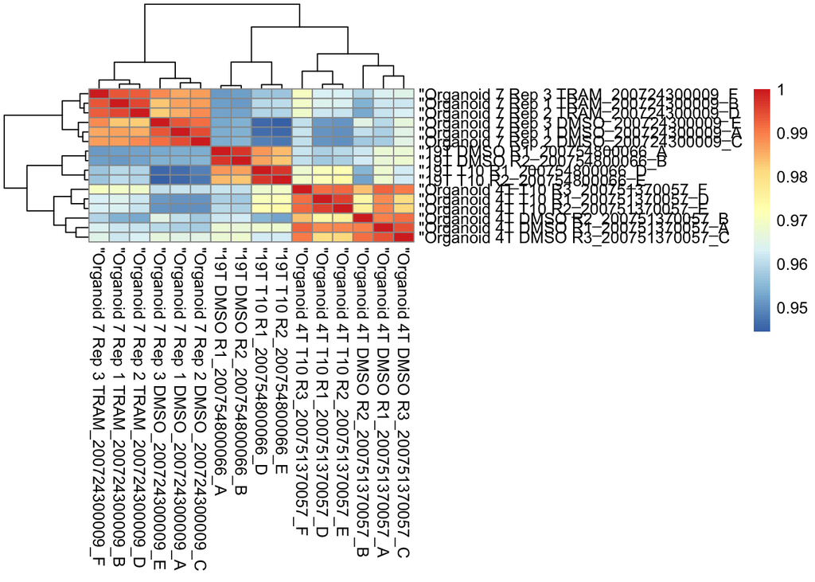

```r
expr_mat <- expr_mat[,!grepl(' P5 | P10 ', colnames(expr_mat))]

## visualize as heatmap
pheatmap(cor(expr_mat))
```

As expected we see the biggest differences between the organoid lines but within each line trametinib and DMSO treated samples are distinguishable.

## Differential gene expression

```r
## sample info (line + treatment)
sample_info <- tibble(names = colnames(expr_mat)) %>%
  mutate(treatment = ifelse(grepl('TRAM|T10', names), 'MEKi', 'DMSO'),
         line = gsub('^\"Organoid ', '', names)) %>%
  separate(line, c('line', 'rest'), extra = 'merge', sep = ' ') %>%
  mutate(line = gsub('\"', '', gsub('T', '', line))) %>%
  select(-rest)

## check matrix and sample info fit together
stopifnot(identical(colnames(expr_mat), sample_info$names))

## model matrix for DGE analysis, general meki effect, regress line effects
mm1 <- model.matrix(~line + treatment, data = sample_info)
mm2 <- model.matrix(~treatment, data = subset(sample_info, line == '19'))

## fit model
fit <- lmFit(expr_mat, mm1)
fit <- eBayes(fit)

## fit additional model for line 19 only
fit19 <- lmFit(expr_mat[,sample_info$line == '19'], mm2)
fit19 <- eBayes(fit19)

## make a results table and map probes to gene symbols
data('probe_mapping_ilmn', package='MEKWnt2018')
mek_res <- topTable(fit, coef = 'treatmentMEKi', n = Inf) %>%
  as_tibble(rownames = 'ProbeID') %>%
  left_join(probe_mapping_ilmn)
mek_res19 <- topTable(fit19, coef = 'treatmentMEKi', n = Inf) %>%
  as_tibble(rownames = 'ProbeID') %>%
  left_join(probe_mapping_ilmn)
```

We visualize a number of high ranking genes to validate the analysis.

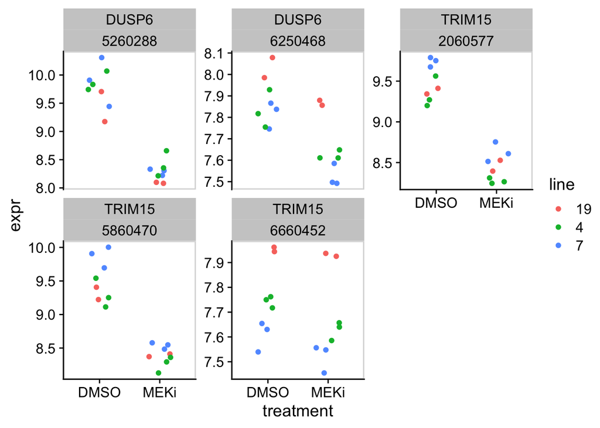

```r
expr_long <- expr_mat %>% as_tibble(rownames = 'ProbeID') %>%
  left_join(probe_mapping_ilmn) %>%
  pivot_longer(names_to = 'names', values_to = 'expr', -c(ProbeID, Entrez_Gene_ID, Symbol)) %>%
  inner_join(sample_info)

## plot examples
expr_long %>% filter(Symbol %in% c('TRIM15', 'DUSP6')) %>%
  ggplot(aes(treatment, expr, color = line)) +
  geom_jitter(width = 0.2) +
  facet_wrap(~ Symbol + ProbeID, scales = 'free_y') +
  panel_border()
```

## Gene set enrichment

Since there is a decent signal in the combined DGE test and the MEK inhibitor phenotype is visible in all lines we proceed with gene set enrichment analysis.

### Gene Ontology

We use the clusterProfiler + fgsea packages to perform a ranked gene set enrichment analysis in order to identify differentially expressed pathways.

```r
## select strongest probe for each entrez id
res_filtered <- mek_res %>% group_by(Entrez_Gene_ID) %>%
  top_n(1, -P.Value) %>% ungroup()

## create ranked list for enrichment
ranks <- setNames(res_filtered$t, as.character(res_filtered$Entrez_Gene_ID))
ranks <- sort(ranks, decreasing = T)

## GO term enrichment (biological process)
gse_go <- gseGO(
  geneList = ranks,
  OrgDb = org.Hs.eg.db,
  ont = 'BP',
  eps = 0,
  minGSSize = 100,
  maxGSSize = 500
)
```

We can generate a network plot using clusterProfiler in order to get an overview of the results.

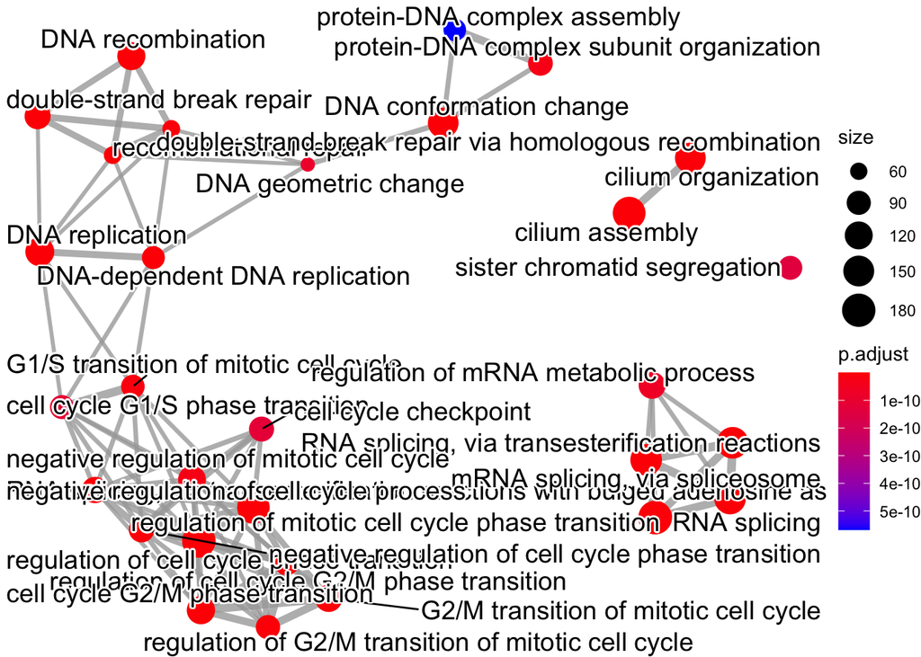

```r
emapplot(pairwise_termsim(gse_go))
```

### Reactome

We do the same for Reactome instead of GO terms. A convenience function for enrichment against Reactome is implemented in the ‘ReactomePA’ package. Conceptually this function works the same way as the clusterProfiler functions.

```r
## Reactome enrichment analysis
gse_reactome <- gsePathway(
  geneList = ranks,
  organism = 'human',
  minGSSize = 100,
  maxGSSize = 500,
  eps = 0
)
```

Again we plot an enrichment map to visualize the results.

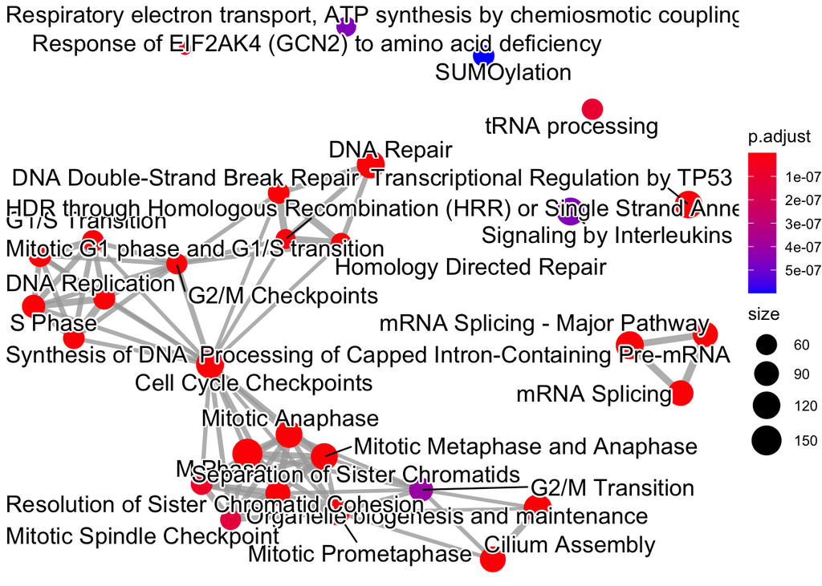

```r
emapplot(pairwise_termsim(gse_reactome))
```

### Intestinal crypt signatures

We perform GSEA for the humanized intestinal crypt signatures published in Merloz-Suarez et al (Cell Stem Cell, 2011).

```r
## parse signatures and make list
intestinal_sig <- readxl::read_excel(here('../../data/gene_expression/merloz-suarez_sigantures.xls'),
                                     sheet = 1, skip = 4) %>% .[,1:4] %>%
  gather(signature, symbol) %>% drop_na() %>%
  mutate(symbol = gsub('\\*', '', symbol))

## run gsea with clusterprofiler
res_symbol <- mek_res %>%
  group_by(Symbol) %>% arrange(P.Value) %>% slice(1) %>% ungroup()
ranks_symbol <- sort(setNames(res_symbol$t, res_symbol$Symbol), decreasing = T)

gse_sig <- GSEA(
  geneList = ranks_symbol,
  TERM2GENE = intestinal_sig,
  minGSSize = 1,
  maxGSSize = 1000,
  eps = 0,
  pvalueCutoff = 1
)

## output as tibble
gse_sig_tbl_ilmn <- as_tibble(gse_sig)

## run again for line 19 results only
res_symbol19 <- mek_res19 %>%
  group_by(Symbol) %>% arrange(P.Value) %>% slice(1) %>% ungroup()
ranks_symbol19 <- sort(setNames(res_symbol19$t, res_symbol19$Symbol), decreasing = T)

gse_sig19 <- GSEA(
  geneList = ranks_symbol19,
  TERM2GENE = intestinal_sig,
  minGSSize = 1,
  maxGSSize = 1000,
  eps = 0,
  pvalueCutoff = 1
)

## output as tibble
gse_sig_tbl_ilmn19 <- as_tibble(gse_sig19)
```

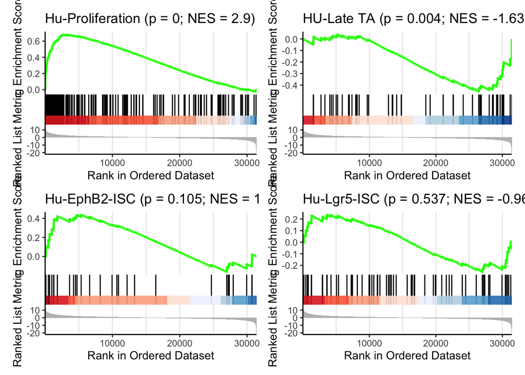

```r
bc_plots <- map(1:nrow(gse_sig_tbl_ilmn), ~ {
  gseaplot2(
    gse_sig, geneSetID = gse_sig$ID[.x],
      title = paste0(gse_sig$ID[.x],
                    ' (p = ', round(gse_sig_tbl_ilmn$pvalue[.x], 3),
                    '; NES = ', round(gse_sig_tbl_ilmn$NES[.x], 2), ')')
  )
})

reduce(bc_plots, `+`)
```

There is a strong upregulation of the proliferation signature, but both stemness signatures remain unchanged.

#### Line 19 only

We plot the GSEA results for line 19 only so we can compare with the Affymetrix data.

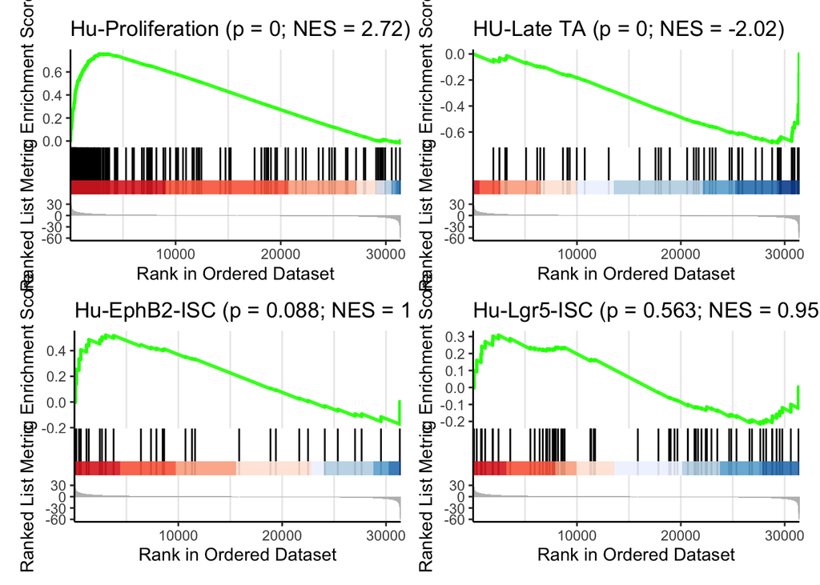

```r
bc_plots <- map(1:nrow(gse_sig19), ~ {
  gseaplot2(
    gse_sig19, geneSetID = gse_sig19$ID[.x],
      title = paste0(gse_sig19$ID[.x],
                    ' (p = ', round(gse_sig_tbl_ilmn19$pvalue[.x], 3),
                    '; NES = ', round(gse_sig_tbl_ilmn19$NES[.x], 2), ')')
  )
})

reduce(bc_plots, `+`)
```

# Affymetrix chip

We generated additional microarrays using an Affymetrix chip where we treated organoid line 19 with Trametinib and DMSO. Do these experiments match with the ones done using Illumina chips?

We start by loading and normalizing the data from CEL files.

```r
## list of cel files
cel_files <- list.files(here('../../data/gene_expression/mek_inhibitor/MEK_inhibition/'),
                        full.names = T, pattern = '.CEL')

## parse and normalize
affy_batch <- ReadAffy(filenames = cel_files)
expr_mat <- expresso(
  affy_batch,
  bgcorrect.method = 'rma',
  normalize.method = 'quantiles',
  pmcorrect.method = 'pmonly',
  summary.method = 'avgdiff'
)
expr_mat <- log(exprs(expr_mat))

## create an annotation for the samples
sample_info <- tibble(names = colnames(expr_mat)) %>%
  extract(names, c('line', 'treatment', 'rep'),
          regex = '^GSM.+Org_(19T)_(.+?)_R([1,2])_HG.+?', remove = F)

## create an annotation for the probe IDs
load(here('../../data/gene_expression/promise_expr.rda'))
probe_anno <- promise_expr %>% distinct(probe, symbol, entrez)
## confirm that chip model was the same
table(probe_anno$probe %in% rownames(expr_mat))
```

## Differential gene expression

Next we perform the same DGE analysis as above (except that we don’t have to regress out line-specific differences).

```r
## check matrix and sample info fit together
stopifnot(identical(colnames(expr_mat), sample_info$names))

## model matrix for DGE analysis, general meki effect, regress line effects
mm <- model.matrix(~treatment, data = sample_info)
## fit model
fit <- lmFit(expr_mat, mm)
fit <- eBayes(fit)

## make a results table and map probes to gene symbols
mek_res_affy <- topTable(fit, coef = 'treatmentDMSO_+_TRAM', n=Inf) %>%
  as_tibble(rownames = 'probe') %>%
  left_join(probe_anno)
```

There are 47 significant changes <5% FDR. I plot some of the highest ranking genes.

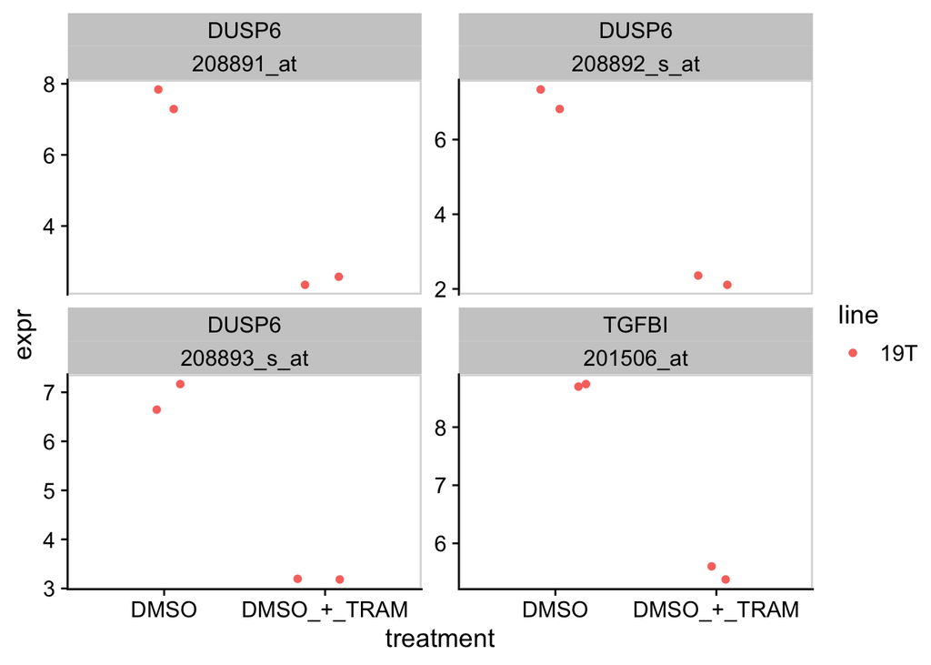

```r
expr_long_affy <- expr_mat %>% as_tibble(rownames = 'probe') %>%
  left_join(probe_anno) %>%
  pivot_longer(names_to = 'names', values_to = 'expr', -c(probe, entrez, symbol)) %>%
  inner_join(sample_info)

## plot examples
expr_long_affy %>% filter(symbol %in% c('TGFBI', 'DUSP6')) %>%
  ggplot(aes(treatment, expr, color = line)) +
  geom_jitter(width = 0.2) +
  facet_wrap(~ symbol + probe, scales = 'free_y') +
  panel_border()
```

The small number of significant differences is simply due to the fact that we have very limited sample sizes (n = 2 per treatment). DUSP6 is the top hit, which was also a hit in the Illumina analysis.

Do the hits overlap with the Illumina based hit list. This list is based also other lines so we would not expect perfect overlap but some correlation should be visible.

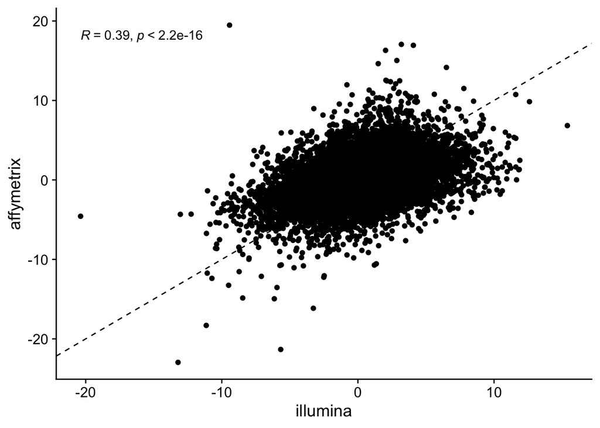

```r
## illumina t statistics
mek_ilmn_t <- mek_res %>% group_by(Symbol) %>%
  top_n(1, -P.Value) %>% ungroup() %>%
  select(symbol = Symbol, illumina = t)

## affymetrix
mek_affy_t <- mek_res_affy %>% group_by(symbol) %>%
  top_n(1, -P.Value) %>% ungroup() %>%
  select(symbol, affymetrix = t)

## compare
mek_ilmn_t %>% inner_join(mek_affy_t) %>%
  ggplot(aes(illumina, affymetrix)) +
  geom_point() +
  geom_abline(linetype = 'dashed') +
  ggpubr::stat_cor()
```

There is decent correlation.

## Gene set enrichment

We perform the same gene set enrichment analysis as above.

### Gene ontology

```r
## select strongest probe for each entrez id
res_filtered <- mek_res_affy %>% group_by(entrez) %>%
  top_n(1, -P.Value) %>% ungroup()

## create ranked list for enrichment
ranks <- setNames(res_filtered$t, as.character(res_filtered$entrez))
ranks <- sort(ranks, decreasing = T)

## GO term enrichment (biological process)
gse_go <- gseGO(
  geneList = ranks,
  OrgDb = org.Hs.eg.db,
  ont = 'BP',
  eps = 0,
  minGSSize = 100,
  maxGSSize = 500
)
```

We can generate a network plot using clusterProfiler in order to get an overview of the results.

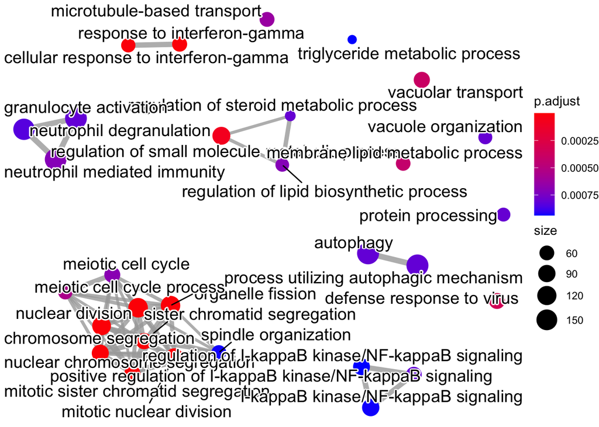

```r
emapplot(pairwise_termsim(gse_go))
```

### Intestinal crypt signatures

```r
## run gsea with clusterprofiler
res_symbol <- mek_res_affy %>%
  group_by(symbol) %>% arrange(P.Value) %>% slice(1) %>% ungroup()
ranks_symbol <- sort(setNames(res_symbol$t, res_symbol$symbol), decreasing = T)

gse_sig_affy <- GSEA(
  geneList = ranks_symbol,
  TERM2GENE = intestinal_sig,
  minGSSize = 1,
  maxGSSize = 1000,
  eps = 0,
  pvalueCutoff = 1
)

## output as tibble
gse_sig_tbl_affy <- as_tibble(gse_sig_affy)
```

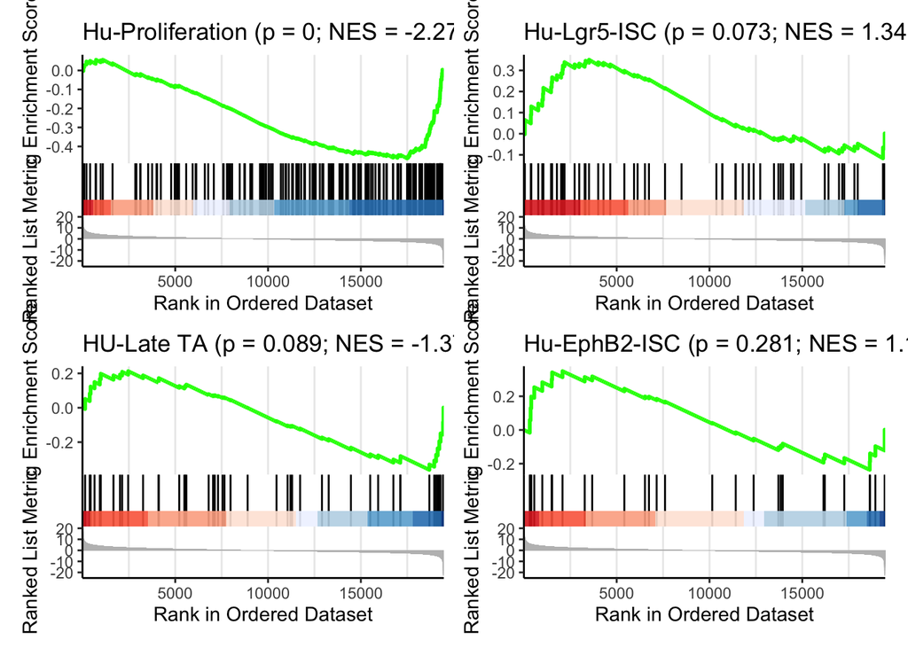

```r
bc_plots <- map(1:nrow(gse_sig_tbl_affy), ~ {
  gseaplot2(
    gse_sig_affy, geneSetID = gse_sig_affy$ID[.x],
      title = paste0(gse_sig_affy$ID[.x],
                    ' (p = ', round(gse_sig_tbl_affy$pvalue[.x], 3),
                    '; NES = ', round(gse_sig_tbl_affy$NES[.x], 2), ')')
  )
})

reduce(bc_plots, `+`)
```

Strangely the intestinal signature enrichment results do not fit together. Proliferation is strongly upregulated based on the Illumina data (including 3 lines), but downregulated in the Affymetrix data (line 19 only). We compare the core_enrichment genes between the two test results.

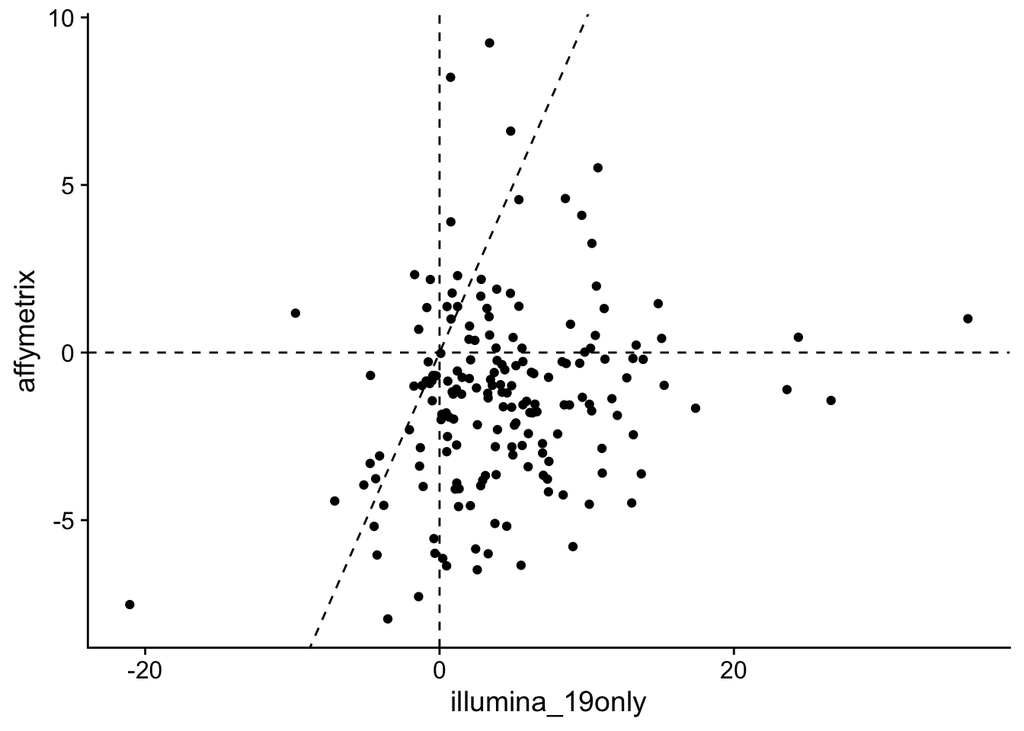

```r
## genes driving illumina enrichment
ce19_ilmn <- gse_sig_tbl_ilmn19 %>%
  separate_rows(core_enrichment, sep = '/') %>%
  pull(core_enrichment)

## genes driving affymetrix enrichment
ce19_affy <- gse_sig_tbl_affy %>%
  separate_rows(core_enrichment, sep = '/') %>%
  pull(core_enrichment)

## is there overlap?
#overlap <- intersect(ce19_affy, ce19_ilmn)
overlap <- signatures$Proliferation

## compare gene expression
compare_t <- mek_res19 %>% filter(Symbol %in% overlap) %>%
  group_by(Symbol) %>% top_n(1, -P.Value) %>% ungroup() %>%
  select(symbol = Symbol, illumina_19only = t) %>%
  inner_join(mek_res_affy %>% filter(symbol %in% overlap) %>%
               group_by(symbol) %>% top_n(1, -P.Value) %>% ungroup() %>%
               select(symbol, affymetrix = t))

## plot scatter
compare_t %>% ggplot(aes(illumina_19only, affymetrix)) +
  geom_point() +
  geom_abline(linetype = 'dashed') +
  geom_vline(xintercept = 0, linetype = 'dashed') +
  geom_hline(yintercept = 0, linetype = 'dashed')
```

There is a bunch of stuff that seems downregulated in the affymetrix data, but for which I don’t see anything in the Illumina data.